# Simulator tutorial: simulate and @mgp

PhyloPOMP.jl, 2026-10-05

## Run this now

```bash
quarto render docs/tutorial/simulator_tutorial.qmd
```

Run it from the PhyloPOMP.jl directory. It writes `docs/tutorial/simulator_tutorial.html`. Open that file in a browser.

Time to expect:

1. First render on a new machine or after a package update: up to several minutes. Julia compiles the packages once.
2. Later renders: under 1 minute.
3. In your own Julia session, `using PhyloPOMP` takes about 20 seconds.
4. The first call to `simulate` takes about 2 seconds. Later calls take milliseconds.

Every code cell below runs top to bottom. Read the output under each cell, then read the text.

## Setup

```julia
import Pkg
Pkg.activate(joinpath(@__DIR__, "simulator"))   # this tutorial's own environment
Pkg.instantiate()

ENV["GKSwstype"] = "100"  # headless GR, no display needed

using PhyloPOMP
using Plots
using Random: MersenneTwister

default(size=(650,300), legend=false)
```

```
  Activating project at `~/Desktop/Projects/PhyloPOMP.jl/docs/tutorial/simulator`
```

## 1. What the simulator does

Run this cell first. It lists the three events of the built-in `SIR` model and how often each one happens right now.

```julia
θ  = (β = 4.0, γ = 1.0, ψ = 0.3, N = 100.0)
x0 = (S = 99, I = 1, R = 0)

rates = [(ev.name, ev.hazard(x0, θ)) for ev in SIR.events]
for (name, rate) in rates
    println(rpad(string(name), 10), " rate = ", rate)
end

total = sum(last, rates)
println("total rate        = ", total)
println("mean wait         = ", round(1 / total, digits = 3))
println("P(next = infection) = ", round(rates[1][2] / total, digits = 3))
```

```
infection  rate = 3.96
recovery   rate = 1.0
sampling   rate = 0.3
total rate        = 5.26
mean wait         = 0.19
P(next = infection) = 0.753
```

The picture:

- A **compartment** is a count of hosts in one state. `S` is susceptible (can be infected), `I` is infected, `R` is recovered.
- An **event** changes the counts. Infection moves one host from `S` to `I`.
- A **rate** (called `hazard` in the code) says how often an event happens per unit of time. It depends on the current counts.
- A **genealogy** is a tree. Its leaves are the infected hosts that were sampled. Its branch points are infections.

The simulator plays an epidemic forward and builds that tree. It uses the Doob-Gillespie algorithm. The cell above did steps 1 and 2 by hand.

1. Compute the rate of every event from the current counts.
2. Add the rates. Call the sum `total`. If `total` is 0, stop.
3. Draw a waiting time. Its mean is `1/total`. If it goes past `tmax`, stop.
4. Pick one event. Event `k` is picked with probability `rate_k / total`.
5. Change the counts as the event says. Change the tree as the event says. Go to step 1.

## 2. Your first simulation

Run this cell.

```julia
g = simulate(SIR, θ; x0 = x0, graft = [1], tmax = 2.0, rng = MersenneTwister(1))

println("samples: ", nsample(g))
println(only(newick(g)))
```

```
samples: 3
((([&&PhyloPOMP type=sample]:0.866039)[&&PhyloPOMP type=sample]:0.0612303,[&&PhyloPOMP type=sample]:0.110403)[&&PhyloPOMP type=node]:0.89968);
```

What you gave `simulate`:

| Argument | Meaning |
| --- | --- |
| `SIR` | The model. |
| `θ` | Parameter values, a `NamedTuple`. Names must match the model’s `params`. |
| `x0` | Starting count in every compartment. |
| `graft` | Number of founding lineages in each deme. Here one. Section 5 defines deme. |
| `tmax` | Stop time. Time units are arbitrary. |
| `rng` | Random number generator. `MersenneTwister(1)` gives the same tree every time. |

What came back:

- `nsample(g)` is the number of sampled hosts in the tree.
- `newick(g)` writes the tree as text. Newick is a standard text format for trees. Parentheses nest. The number after a colon is the length of the branch above that node.
- The result is a list with one string per founder. Here there is one founder.
- The bracket `[&&PhyloPOMP type=sample]` labels each node with its type. Section 3 explains the types and draws this tree.

Now the same model for 20 time units, many runs.

```julia
counts = [nsample(simulate(SIR, θ; x0 = x0, graft = [1], tmax = 20.0,
                           rng = MersenneTwister(s))) for s in 1:1000]

println("runs:                 ", length(counts))
println("runs with no samples: ", count(==(0), counts))
println("mean samples per run: ", round(sum(counts) / length(counts), digits = 1))
```

```
runs:                 1000
runs with no samples: 246
mean samples per run: 21.2
```

An empty tree is a normal result. The first infected host can recover before anyone is sampled. Then `nsample(g) == 0`.

## 3. Reading the tree

Run this cell. It prints every node of the tree from Section 2.

```julia
for i in eachindex(g.nodes)
    n = g[i]
    println("node ", i, ": ", rpad(string(n.type), 7),
            " time=", round(n.slate, digits = 3),
            "  parent=", n.parent,
            "  children=", Int.(n.children))
end
println("tree starts at ", g.t0, " and ends at ", g.time)
```

```
node 1: Root    time=0.0  parent=nothing  children=[2]
node 2: Node    time=0.9  parent=1  children=[3, 4]
node 3: Sample  time=0.961  parent=2  children=[5]
node 4: Sample  time=1.01  parent=2  children=Int64[]
node 5: Sample  time=1.827  parent=3  children=Int64[]
tree starts at 0.0 and ends at 2.0
```

`g[i]` is node `i`. Its fields:

- `.type` is the node type.
- `.slate` is the node’s time.
- `.parent` is the index of the parent, or `nothing`.
- `.children` is the list of child indices.
- `.deme` is `missing` here. Section 8 fills it.

The three node types:

| Type | Meaning | Children |
| --- | --- | --- |
| `Root` | Start of a founder lineage. | 1 |
| `Node` | A branch point. One lineage became two. That is an infection. | 2 |
| `Sample` | A host was sampled at this time. | 0 if the sample removed the host, at most 1 if the host kept going |

Compare with the printout. Node 1 is the `Root`. Node 2 is a `Node` with two children. Node 3 is a `Sample` with one child: that host was sampled, kept going, and was sampled again later.

### Draw the tree

Run this cell. It draws the tree from Section 2. Time runs left to right. Each dot is a sampled host.

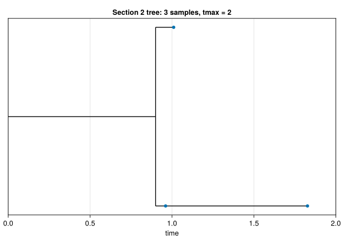

```julia
import CairoMakie   # loading a Makie backend turns on `genealogyplot`

genealogyplot(g, title = "Section 2 tree: 3 samples, tmax = 2")
```

`genealogyplot` returns a Makie figure. It needs a Makie backend loaded, such as `CairoMakie`. Without one, `genealogyplot` has no method. This is the same arrangement `PartiallyObservedMarkovProcesses` uses for `sliceplot` and `traceplot`.

How to read it:

1. The line at the far left is the `Root`. It is the first infected host.
2. A vertical line is a `Node`. One lineage became two: an infection.
3. A dot is a `Sample`.
4. A dot with a line after it is a host that was sampled and kept going. The lower sample in this tree is one.

Options: `ladderize` (default `true`, puts smaller clades first), `points` (default `true`), `palette`, `title`.

Now a bigger tree: the same model and seed, run to `tmax = 3`.

```
samples: 10
```

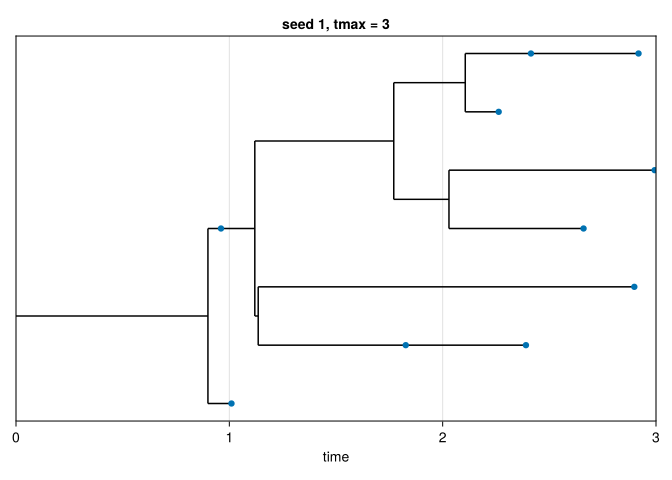

```julia
g3 = simulate(SIR, θ; x0 = x0, graft = [1], tmax = 3.0, rng = MersenneTwister(1))
println("samples: ", nsample(g3))
genealogyplot(g3, title = "seed 1, tmax = 3")
```

Same seed, so the first events are the same. More time means more samples, so more branches stay in the tree.

The exported helpers return node indices:

```julia
println("nodes(g)   = ", nodes(g))
println("samples(g) = ", samples(g))
println("roots(g)   = ", roots(g))
println("tips(g)    = ", tips(g), "   (nodes with no children)")
println("is node 4 a Sample? ", g[4].type == PhyloPOMP.Sample)
```

```
nodes(g)   = [2]
samples(g) = [3, 4, 5]
roots(g)   = [1]
tips(g)    = [4, 5]   (nodes with no children)
is node 4 a Sample? true
```

`Root`, `Node` and `Sample` are not exported. Write `PhyloPOMP.Sample`, or compare `string(g[i].type)`.

The tree is pruned. Only sampled hosts and their ancestors remain. Hosts that were never sampled are removed.

## 4. The population over time

Run this cell. `simulate_trajectory` returns the tree and the counts after every event.

```julia
r = simulate_trajectory(SIR, θ; x0 = x0, graft = [1], tmax = 20.0, rng = MersenneTwister(3))

println("fields:        ", keys(r))
println("events fired:  ", length(r.events))
println("length(times)  = ", length(r.times), ",  length(states) = ", length(r.states))
println("first events:  ", r.events[1:5])
println("first state:   ", r.states[1])
println("last state:    ", r.states[end])
println("last event at: ", round(r.times[end], digits = 2))
println("samples:       ", nsample(r.genealogy))
```

```
fields:        (:genealogy, :times, :states, :events)
events fired:  237
length(times)  = 238,  length(states) = 238
first events:  [:infection, :sampling, :infection, :infection, :infection]
first state:   (S = 99, I = 1, R = 0)
last state:    (S = 5, I = 0, R = 95)
last event at: 6.92
samples:       48
```

What the fields hold:

- `genealogy` is the tree. It equals what `simulate` returns for the same seed.
- `times` is `t0`, then the time of each event.
- `states` is `x0`, then the counts after each event. It is as long as `times`.
- `events` is the name of each event. It is one shorter than `times`.

Plot the number of infected hosts:

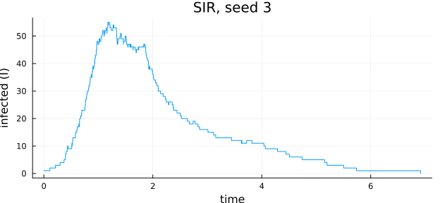

```julia
plot(r.times, [s.I for s in r.states], seriestype = :steppost,
     xlabel = "time", ylabel = "infected (I)", title = "SIR, seed 3")
```

The epidemic rises, peaks, and ends when `I` reaches 0. Nothing happens after that, so the last event is before `tmax`. The counts cover the whole population. Pruning removes lineages from the tree only.

## 5. Write your own model with `@mgp`

Run this cell. It defines `MySIR`, a copy of the built-in `SIR`.

```julia
@mgp MySIR begin
    compartments = (S, I, R)
    demes = (I,)
    params = (β, γ, ψ, N)

    @event infection rate=β*S*I/N pop=(S=-1, I=+1) move=fork(I => I, I) kind=regular
    @event recovery  rate=γ*I     pop=(I=-1, R=+1) move=chop(I)         kind=regular
    @event sampling  rate=ψ*I     pop=()           move=sample(I)       kind=singular
end

mine    = simulate(MySIR, θ; x0 = x0, graft = [1], tmax = 20.0, rng = MersenneTwister(3))
builtin = simulate(SIR,   θ; x0 = x0, graft = [1], tmax = 20.0, rng = MersenneTwister(3))
println("same tree as the built-in SIR? ", newick(mine) == newick(builtin))
println("nsample = ", nsample(mine))
```

```
same tree as the built-in SIR? true
nsample = 48
```

Same model and same seed give the same tree.

The three declaration lines:

| Line | Meaning |
| --- | --- |
| `compartments` | Every count the model tracks. |
| `demes` | The compartments whose hosts carry a lineage in the tree. A **deme** is one such group. |
| `params` | Parameter names. They must not repeat a compartment name. |

The five parts of each `@event`:

| Part | Meaning |
| --- | --- |
| name | A label, such as `infection`. |
| `rate=` | A Julia expression. The macro replaces `S` with `x.S` and `β` with `θ.β`. |
| `pop=` | The change to each compartment. `()` means no change. |
| `move=` | What happens to lineages in the tree. See the table below. |
| `kind=` | `regular` (default) or `singular`. `singular` marks events that leave a mark in the tree, such as sampling. `simulate` ignores `kind`. The likelihood filters use it. |

The six moves:

| Move | Meaning |
| --- | --- |
| `fork(A => B, C)` | A lineage in deme A splits. Afterwards one lineage is in B and one is in C. Exactly two products. |
| `swap(A => B)` | One lineage moves from deme A to deme B. |
| `chop(A)` | A lineage in A ends without being sampled. |
| `sample(A)` | A lineage in A is sampled and keeps going. |
| `sample_remove(A)` | A lineage in A is sampled and ends. |
| `none` | No lineage is involved. |

The macro made two things. `MySIR` is the model. `MySIRDemes` is a module with one value per deme:

```julia
println(typeof(MySIR))
println(MySIRDemes.I)
```

```
MGPModel
I
```

Now turn it into an SIRS model. In SIRS, recovered hosts lose immunity and become susceptible again.

1. Add the parameter `ω` to `params`.
2. Add one `@event` that moves `R` back to `S`.
3. Use `move=none`, because no lineage is involved.

```
waning events: 463
last state:    (S = 16, I = 25, R = 59)
samples:       166
```

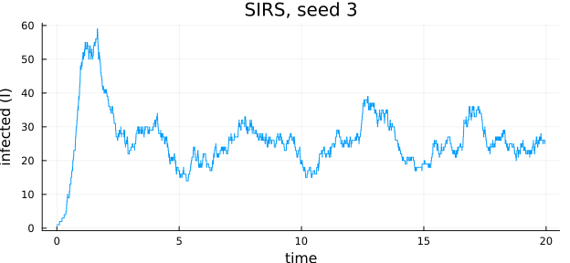

```julia
@mgp MySIRS begin
    compartments = (S, I, R)
    demes = (I,)
    params = (β, γ, ψ, N, ω)

    @event infection rate=β*S*I/N pop=(S=-1, I=+1) move=fork(I => I, I) kind=regular
    @event recovery  rate=γ*I     pop=(I=-1, R=+1) move=chop(I)         kind=regular
    @event sampling  rate=ψ*I     pop=()           move=sample(I)       kind=singular
    @event waning    rate=ω*R     pop=(R=-1, S=+1) move=none            kind=regular
end

θs = merge(θ, (ω = 0.5,))
rs = simulate_trajectory(MySIRS, θs; x0 = x0, graft = [1], tmax = 20.0, rng = MersenneTwister(3))

println("waning events: ", count(==(:waning), rs.events))
println("last state:    ", rs.states[end])
println("samples:       ", nsample(rs.genealogy))

plot(rs.times, [s.I for s in rs.states], seriestype = :steppost,
     xlabel = "time", ylabel = "infected (I)", title = "SIRS, seed 3")
```

With `ω = 0.5` the epidemic does not end at the first wave. Immunity is lost, so `S` refills. `I` is still above 0 at `tmax`.

## 6. The rule `pop` must obey

Run this cell. The macro refuses an event whose `pop` disagrees with its `move`.

```julia
function show_error(f)
    try
        f()
    catch e
        while e isa LoadError
            e = e.error
        end
        println(typeof(e), ": ", e.msg)
    end
end

show_error() do
    eval(:(@mgp WrongPop begin
        compartments = (S, E, I, R)
        demes = (E, I)
        params = (β, N)
        @event infection rate=β*S*I/N pop=(S=-1) move=fork(I => E, I)
    end))
end
```

```
ErrorException: @event infection: `move` changes the lineage count of deme `E` by 1 but `pop` declares 0; lineages and population must agree
```

The cause:

1. Each host in a deme carries one lineage. So lineages in a deme and hosts in that compartment must change together.
2. `fork(I => E, I)` adds one lineage to deme `E`. It keeps one in `I`, which was already there.
3. `pop=(S=-1)` does not add a host to `E`. The two disagree.

The rule: for each deme, `pop` must equal the change in lineages that `move` implies. That is the number of products in that deme, minus 1 for the source deme. Compartments that are not demes are free. Here `S` is not a deme, so `S=-1` is fine.

The fix:

```julia
@mgp FixedPop begin
    compartments = (S, E, I, R)
    demes = (E, I)
    params = (β, ψ, N)
    @event infection rate=β*S*I/N pop=(S=-1, E=+1) move=fork(I => E, I)
    @event sampling  rate=ψ*I     pop=()           move=sample(I)      kind=singular
end

θf = (β = 4.0, ψ = 0.3, N = 100.0)
gf = simulate(FixedPop, θf; x0 = (S = 99, E = 0, I = 1, R = 0), graft = [0, 1],
              tmax = 5.0, rng = MersenneTwister(1))
println("FixedPop runs. samples: ", nsample(gf))
```

```
FixedPop runs. samples: 2
```

Other mistakes are caught when the macro runs, before any simulation:

```julia
bad_moves = [
    :(@mgp BadMove begin
        compartments = (S, I)
        demes = (I,)
        params = (β,)
        @event f rate=β*S*I pop=(S=-1) move=teleport(I)
    end),
    :(@mgp OneProduct begin
        compartments = (S, I)
        demes = (I,)
        params = (β,)
        @event f rate=β*S*I pop=(S=-1, I=+1) move=fork(I => I)
    end),
    :(@mgp NoRate begin
        compartments = (S, I)
        demes = (I,)
        params = (β,)
        @event f pop=(I=-1) move=chop(I)
    end),
]

for ex in bad_moves
    show_error(() -> eval(ex))
end
```

```
ErrorException: @event: unknown move `teleport`
ErrorException: @event f: `fork` must list exactly two products (the lineages open after the birth, including the parent if it continues), got 1; use `swap` for a one-to-one deme change
ErrorException: @event f: missing `rate`
```

## 7. Sampling that removes the host and sampling that keeps it

Run this cell. It lists the demes and events of each built-in model.

```julia
for m in (SIR, SEIR, SI2R, MTBD, MERS)
    println(rpad(string(m.name), 5), " demes = ", rpad(join(m.demes, ", "), 10),
            " events = ", join((e.name for e in m.events), ", "))
end
```

```
SIR   demes = I          events = infection, recovery, sampling
SEIR  demes = E, I       events = infection, progression, recovery, waning, sampling, culling
SI2R  demes = I_L, I_H   events = TL, TH, L, H, RL, RH, W, SL, SH, SL_remove, SH_remove
MTBD  demes = I1, I2     events = birth11, birth12, birth21, birth22, migrate12, migrate21, death1, death2, sample_remove1, sample_remove2, sample1, sample2
MERS  demes = I_c, I_h   events = transmission_cc, transmission_hh, transmission_hc, transmission_ch, removal_c, removal_h, sampling_c, sampling_h, birth_c, birth_h, death_c, death_h
```

A sample can end the host’s lineage or let it continue. This is a model parameter, not an option of `simulate`. The likelihood code reads the same event table.

| Model | Keeps the host | Removes the host |
| --- | --- | --- |
| `SIR` | `sampling` | not in this model |
| `SEIR` | rate `ψ`, `move=sample(I)` | rate `χ`, `move=sample_remove(I)` |
| `SI2R` | rate `(1-r)*ψ` | rate `r*ψ` |
| `MTBD` | rate `(1-r1)*psi1`, `(1-r2)*psi2` | rate `r1*psi1`, `r2*psi2` |

`SEIR`, `SI2R` and `MTBD` are defined in `src/examples/`. `MERS` has camels and humans as two demes.

To see the effect, count the `Sample` nodes that have a child. Such a host was sampled and kept going. The cell uses 20 seeds per row.

```julia
with_child(g) = count(i -> !isempty(g[i].children), samples(g))

function summarize(model, θ, x0, graft, tmax)
    total, kept = 0, 0
    for s in 1:20
        g = simulate(model, θ; x0 = x0, graft = graft, tmax = tmax, rng = MersenneTwister(s))
        total += Int(nsample(g))
        kept  += with_child(g)
    end
    (samples = total, with_child = kept)
end

θ_seir = (β = 4.0, σ = 1.0, γ = 1.0, ω = 1.0, ψ = 0.3, χ = 0.0, N = 100.0)
x_seir = (S = 99, E = 0, I = 1, R = 0)

θ_si2r = (β = 4.0, κ = 3.0, γ = 1.0, ω = 0.5, ψ = 0.3, η_L = 0.5, η_H = 1.0, N = 100.0, r = 1.0)
x_si2r = (S = 99, I_L = 1, I_H = 0, R = 0)

θ_mtbd = (lambda11 = 1.2, lambda12 = 0.3, lambda21 = 0.2, lambda22 = 0.9, m12 = 0.2, m21 = 0.1,
          mu1 = 0.5, mu2 = 0.5, psi1 = 0.3, psi2 = 0.3, r1 = 0.7, r2 = 1.0)
x_mtbd = (I1 = 1, I2 = 0)

rows = [
    "SEIR  keep   (ψ=0.3, χ=0)" => summarize(SEIR, merge(θ_seir, (ψ = 0.3, χ = 0.0)), x_seir, [0, 1], 20.0),
    "SEIR  remove (ψ=0, χ=0.3)" => summarize(SEIR, merge(θ_seir, (ψ = 0.0, χ = 0.3)), x_seir, [0, 1], 20.0),
    "SI2R  keep   (r=0)"        => summarize(SI2R, merge(θ_si2r, (r = 0.0,)), x_si2r, [1, 0], 20.0),
    "SI2R  remove (r=1)"        => summarize(SI2R, merge(θ_si2r, (r = 1.0,)), x_si2r, [1, 0], 20.0),
    "MTBD  keep   (r1=r2=0)"    => summarize(MTBD, merge(θ_mtbd, (r1 = 0.0, r2 = 0.0)), x_mtbd, [1, 0], 6.0),
    "MTBD  remove (r1=r2=1)"    => summarize(MTBD, merge(θ_mtbd, (r1 = 1.0, r2 = 1.0)), x_mtbd, [1, 0], 6.0),
]
for (label, s) in rows
    println(rpad(label, 28), s)
end
```

```
SEIR  keep   (ψ=0.3, χ=0)   (samples = 2168, with_child = 810)
SEIR  remove (ψ=0, χ=0.3)   (samples = 909, with_child = 0)
SI2R  keep   (r=0)          (samples = 2660, with_child = 1007)
SI2R  remove (r=1)          (samples = 884, with_child = 0)
MTBD  keep   (r1=r2=0)      (samples = 937, with_child = 280)
MTBD  remove (r1=r2=1)      (samples = 244, with_child = 0)
```

When the sample removes the host, no `Sample` node has a child. When it keeps the host, many do. Removal also takes the host out of the population: the `culling` event has `pop=(I=-1)`. Section 6 explains why.

## 8. Label samples with their deme

Run this cell. It labels each sample with the deme of its host. `MTBD` has two demes, `I1` and `I2`. They are two host types.

```julia
ds = PhyloPOMP.MTBDDemes

gm = simulate(MTBD, θ_mtbd; x0 = x_mtbd, graft = [1, 0], tmax = 6.0,
              rng = MersenneTwister(4),
              demeset = ds, samplemap = [ds.I1, ds.I2])

println(gm)
println(newick(gm))
```

```
<genealogy on [0.0,6.0]:
  1: <root lineage=1 time=0.0 children=[2]>
  2: <node lineage=1 time=1.643 parent=1 children=[3,4]>
  3: <sample lineage=1 deme=I1 time=2.19 parent=2 children=[]>
  4: <node lineage=2 time=2.81 parent=2 children=[5,6]>
  5: <sample lineage=2 deme=I1 time=3.586 parent=4 children=[]>
  6: <sample lineage=3 deme=I2 time=3.74 parent=4 children=[]>>
["(([&&PhyloPOMP type=sample deme=I1]:0.547435,([&&PhyloPOMP type=sample deme=I1]:0.776015,[&&PhyloPOMP type=sample deme=I2]:0.929935)[&&PhyloPOMP type=node]:1.16713)[&&PhyloPOMP type=node]:1.64252);"]
```

Two new keywords did this:

1. `demeset = PhyloPOMP.MTBDDemes` names the module that `@mgp` made for this model. For `MySIRS` it would be `MySIRSDemes`.
2. `samplemap = [ds.I1, ds.I2]` has one entry per deme, in `model.demes` order. The label for a sample from deme `d` is `samplemap[d]`.

Read the labels from the tree:

```julia
for i in samples(gm)
    println("sample ", i, " is in deme ", gm[i].deme)
end
println("node 2 (a branch point) has deme: ", gm[2].deme)
```

```
sample 3 is in deme I1
sample 5 is in deme I1
sample 6 is in deme I2
node 2 (a branch point) has deme: missing
```

Only `Sample` nodes carry a deme. All other nodes have `missing`. Without `demeset` and `samplemap`, every `.deme` is `missing`, as in Section 3.

Draw the tree. `genealogyplot` colors the samples by deme and adds a legend when the tree records demes.

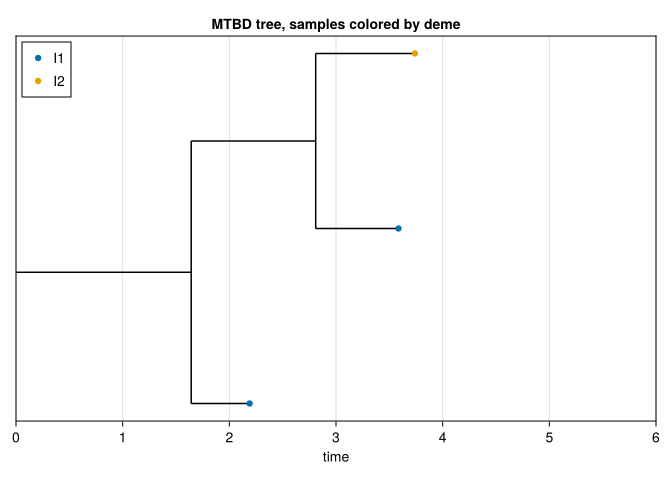

```julia
genealogyplot(gm, title = "MTBD tree, samples colored by deme")
```

## 9. What gets checked for you

Run this cell. `validate_model` returns a list of problems. An empty list means none.

```julia
println("SIR: ", validate_model(SIR))
println("MTBD: ", validate_model(MTBD))
```

```
SIR: String[]
MTBD: String[]
```

`@mgp` builds a correct model by design. A model you build by hand with `MGPModel(...)` and `Event(...)` can be wrong. Here is a birth event that makes one lineage instead of two:

```julia
HalfBirth = MGPModel(:HalfBirth, [:I], [:I], [
    Event(:b, [:I => +1], (x, θ) -> θ.b * x.I, [1], PhyloPOMP.BIRTH, 1, Int[], true, false),
])

for issue in validate_model(HalfBirth)
    println(issue)
end

show_error() do
    simulate(HalfBirth, (b = 1.0,); x0 = (I = 1,), graft = [1], tmax = 1.0)
end
```

```
event `b`: BIRTH has 1 products (sum of r), expected 2
event `b`: Δ changes deme `I` by 1, but r and from imply 0
ArgumentError: model HalfBirth: event `b`: BIRTH has 1 products (sum of r), expected 2; event `b`: Δ changes deme `I` by 1, but r and from imply 0
```

`simulate` calls `validate_model` first. It throws an `ArgumentError` that lists every issue. The fix is `r = [2]` and `into = [1]` for a birth that stays in deme `I`. Or write the model with `@mgp`.

`simulate` also checks its arguments. Each line below breaks one rule:

```julia
show_error(() -> simulate(SIR, θ; x0 = x0, graft = [1, 0], tmax = 5.0))
show_error(() -> simulate(SIR, θ; x0 = (S = 99, I = 1), graft = [1], tmax = 5.0))
show_error(() -> simulate(SIR, θ; x0 = (S = 98, I = 2, R = 0), graft = [1], tmax = 5.0))
show_error(() -> simulate(SIR, θ; x0 = x0, graft = [1], tmax = -1.0))
```

```
ArgumentError: `graft` must have one entry per deme (1), got 2
ArgumentError: `x0` has no entry for compartment `R` of model SIR
ArgumentError: x0.I = 2 must equal graft[1] = 1: forward simulation tracks every extant individual's lineage
ArgumentError: `tmax` = -1.0 must not be earlier than `t0` = 0.0
```

The causes, in order:

1. `graft` has one entry per deme. `SIR` has one deme.
2. `x0` must name every compartment.
3. `x0` for each deme must equal `graft`. Every infected host carries a lineage.
4. `tmax` must not be earlier than `t0`.

One more check happens during the run. A rate must be 0 when the compartment it takes from is empty. This model breaks that rule:

```julia
@mgp Leak begin
    compartments = (S, I)
    demes = (I,)
    params = (ρ,)
    @event drain rate=ρ pop=(S=-1) move=none
end

show_error() do
    simulate(Leak, (ρ = 1.0,); x0 = (S = 3, I = 1), graft = [1], tmax = 20.0,
             rng = MersenneTwister(1))
end
```

```
AssertionError: event drain drove a compartment negative: (S = -1, I = 1) -- its hazard must vanish when a compartment it depletes is empty
```

The cause: the rate `ρ` stays positive after `S` reaches 0. The event fires and `S` goes to -1. That is an `AssertionError`. The fix: write `rate=ρ*S`.

`AssertionError` is also thrown if a rate is negative, infinite or `NaN`.

## 10. Under the hood

Run this cell. It prints what `@mgp` built for the first event of `SIR`.

```julia
ev = SIR.events[1]
for f in fieldnames(typeof(ev))
    f == :hazard && continue
    println(rpad(string(f), 9), getfield(ev, f))
end
println("hazard at x0: ", ev.hazard(x0, θ))
```

```
name     infection
Δ        [:S => -1, :I => 1]
r        [2]
type     BIRTH
from     1
into     [1]
regular  true
observed false
hazard at x0: 3.96
```

The fields of an `Event`:

| Field | Meaning |
| --- | --- |
| `name` | The label. |
| `Δ` | The change to each compartment. This is `pop`. |
| `hazard` | The rate, as a function `(x, θ) -> number`. |
| `r` | Lineages produced in each deme. |
| `type` | `BIRTH`, `MIGRATION`, `DEATH`, `SAMPLE` or `NEUTRAL`. These come from `fork`, `swap`, `chop`, `sample` and `none`. |
| `from`, `into` | The source deme index (0 for none) and the target deme indices. |
| `regular`, `observed` | `kind=regular` gives `regular = true`. `kind=singular` gives `observed = true`. |

`audit_model` prints the whole event table:

```julia
audit_model(SIR)
```

```
ModelAudit(SIR)
  compartments: S, I, R
  demes:        I
  events (3):
  - infection  [BIRTH, regular, background]
      Δ (state jump):     S=-1, I=+1
      α (hazard):         present (closure)
      r (production):     [2]
      W.from (source):    I [deme #1]
      W.into (targets):   I [deme #1]
  - recovery  [DEATH, regular, background]
      Δ (state jump):     I=-1, R=+1
      α (hazard):         present (closure)
      r (production):     [0]
      W.from (source):    I [deme #1]
      W.into (targets):   (none)
  - sampling  [SAMPLE, singular, observed]
      Δ (state jump):     (none)
      α (hazard):         present (closure)
      r (production):     [1]
      W.from (source):    I [deme #1]
      W.into (targets):   (none)
```

`@macroexpand` shows the code the macro writes. This cell expands a one-event model and prints only the model line:

```julia
expanded = Base.remove_linenums!(@macroexpand @mgp Tiny begin
    compartments = (S, I)
    demes = (I,)
    params = (β,)
    @event removal rate=β*I pop=(I=-1) move=chop(I)
end)
println(expanded.args[end])
```

```
const Tiny = MGPModel(:Tiny, [:S, :I], [:I], [Event(:removal, [:I => -1], ((x, θ)->begin
                            θ.β * x.I
                        end), [0], PhyloPOMP.DEATH, 1, Int64[], true, false)])
```

The rate `β*I` became `θ.β * x.I`. The move `chop(I)` became type `DEATH`, source deme 1, and `r = [0]`.

Where the code lives:

| File | Contents |
| --- | --- |
| `src/simulate.jl` | `simulate`, `simulate_trajectory`. |
| `src/examples/mgp_macro.jl` | `@mgp`, and the `SEIR` model. |
| `src/examples/mgp.jl` | `Event`, `MGPModel`. |
| `src/examples/mgp_audit.jl` | `validate_model`, `audit_model`. |
| `src/examples/mgp_sir.jl`, `mgp_si2r.jl`, `mgp_mtbd.jl`, `mgp_mers.jl` | The other built-in models. |

`scripts/mgp_crossvalidate.R` and `scripts/mgp_crossvalidate.jl` compare this simulator with the R package phylopomp.

## 11. Cheat sheet

Run a model:

```julia
g = simulate(Model, θ; x0 = (...), graft = [...], tmax = 20.0, rng = MersenneTwister(1))
r = simulate_trajectory(Model, θ; x0 = (...), graft = [...], tmax = 20.0)   # r.genealogy, r.times, r.states, r.events
```

Keywords of `simulate`:

| Keyword | Meaning |
| --- | --- |
| `x0` | Start count of every compartment. |
| `graft` | Founding lineages per deme, in `model.demes` order. Must equal `x0` for the demes. |
| `tmax` | Stop time. |
| `t0` | Start time. Default 0. |
| `rng` | `MersenneTwister(seed)` for repeatable runs. |
| `demeset`, `samplemap` | Label samples with their deme. Use together. |

Read a tree:

| Call | Result |
| --- | --- |
| `nsample(g)` | Number of samples. 0 means an empty tree. |
| `newick(g)` | Vector of Newick strings, one per founder. |
| `g[i].type`, `.slate`, `.parent`, `.children`, `.deme` | Fields of node `i`. |
| `samples(g)`, `nodes(g)`, `roots(g)`, `tips(g)` | Node indices. |
| `import CairoMakie; genealogyplot(g)` | Draw the tree. Needs a Makie backend. |

Write a model:

```julia
@mgp Name begin
    compartments = (S, I, R)
    demes = (I,)
    params = (β, γ)
    @event infection rate=β*S*I/N pop=(S=-1, I=+1) move=fork(I => I, I)
    @event sampling  rate=ψ*I     pop=()           move=sample(I)  kind=singular
end
```

Moves: `fork(A => B, C)`, `swap(A => B)`, `chop(A)`, `sample(A)`, `sample_remove(A)`, `none`.

Rules:

1. For each deme, `pop` must equal the lineage change that `move` implies.
2. Every rate must be 0 when the compartment it takes from is empty.
3. Parameter names must not repeat compartment names.

Errors:

| Error | Cause |
| --- | --- |
| Macro error at definition | `pop` and `move` disagree, unknown move, `fork` without two products, missing `rate` or `move`. |
| `ArgumentError` from `simulate` | Bad `graft`, `x0`, `samplemap` or `tmax`, or a hand-built model that fails `validate_model`. |
| `AssertionError` from `simulate` | A rate is negative, infinite or `NaN`, or an event fires when its source compartment is empty. |

Inspect: `validate_model(m)`, `audit_model(m)`, `@macroexpand @mgp ...`.

## Next thing to try

In `MySIRS`, set `ω = 0.0` and run with `MersenneTwister(3)`. Compare `newick` of the result with `newick` of the built-in `SIR` run with the same seed. Then set `ω = 0.1` and plot `I` over time.